# edu

## Data cleaning

- Get the coordinates for schools and students
- Get the projection from the TRESO shapefile
- Transform the coordinates to use the same projection system as TRESO shapefile
- *TODO* get rid of Quebec zones

```r
# Convert the student dataframe into SpatialPointsDataframe
student_spdf <- select(student_travel_90, c(studentLat, studentLong, dist, schoolName, Enrolment, student_postal_id)) %>%
  rename(
    lat = studentLat,
    long = studentLong,
    euclidean_dist = dist,
    school_name = schoolName,
    enrolment = Enrolment
    )
coordinates(student_spdf) <- c('long', 'lat')

# Convert the school dataframe into SpatialPointsDataframe
school_spdf <- select(student_travel_90, c(schoolName, schoolLat, schoolLong, DSBINDEX, BSID, SFIS, percDist)) %>%
  group_by(schoolName) %>%
  summarise(schoolLat = first(schoolLat), schoolLong = first(schoolLong),
            dsb = first(DSBINDEX), percDist = first(percDist), sfis = first(SFIS),
            bsid = first(BSID)) %>%
  rename(
    lat = schoolLat,
    long = schoolLong,
    school_name = schoolName,
    catchment_dist = percDist
  ) %>%
  mutate(id = row_number())
coordinates(school_spdf) <- c('long', 'lat')

# Project the student and school points from lat/long to TRESO's LCC specification
proj4string(student_spdf) <- CRS("+proj=longlat +datum=WGS84")
proj4string(school_spdf) <- CRS("+proj=longlat +datum=WGS84")
treso_projarg = treso_shp@proj4string@projargs

student_xy <- spTransform(student_spdf, CRS(treso_projarg))
school_xy <- spTransform(school_spdf, CRS(treso_projarg))
```

- Combine the population, household information
- Summarize by TRESO zones

```r
# Clean hhld_df
hhld_tb <- select(hhld_df, hhid, treso_zone, income) %>%
  as.tibble()

# Clean pop_df and join with hhld
socio_economic_tb <- select(pop_df, hhid, treso_zone, age, hdgree, nocs_11, work_status, school_status) %>%
  as.tibble() %>%
  left_join(hhld_tb, by = c("hhid" , "treso_zone"))

# Summarize into TRESO Zones
treso_tb <- socio_economic_tb %>%
  group_by(treso_zone) %>%
  summarise(
    n_pop = n(),
    n_hhlds = length(unique(hhid)),
    n_ft = length(treso_zone[work_status == "full_time"]),
    n_pt = length(treso_zone[work_status == "part_time"]),
    n_unemp = length(treso_zone[work_status == "unemployed"]),
    n_sec_pop = length(treso_zone[age <= 18 & age >= 13]),
    n_ele_pop = length(treso_zone[age <= 12 & age >= 3]),
    n_pre_pop = length(treso_zone[age <= 2]),

    mean_income = mean(income, na.rm = TRUE),
    mean_age = mean(age, na.rm = TRUE),

    occu_management = length(treso_zone[nocs_11 == 1]),
    occu_business = length(treso_zone[nocs_11 == 2]),
    occu_science = length(treso_zone[nocs_11 == 3]),
    occu_health = length(treso_zone[nocs_11 == 4]),
    occu_public = length(treso_zone[nocs_11 == 5]),
    occu_recreation = length(treso_zone[nocs_11 == 6]),
    occu_sales = length(treso_zone[nocs_11 == 7]),
    occu_trades = length(treso_zone[nocs_11 == 8]),
    occu_production = length(treso_zone[nocs_11 == 9]),
    occu_manufacturing = length(treso_zone[nocs_11 == 10]),
    occu_notapplicable = length(treso_zone[nocs_11 == 99]),
    attend_school = length(treso_zone[school_status == 2]),
    deg_none = length(treso_zone[hdgree == 1]),
    deg_hs = length(treso_zone[hdgree == 2]),
    deg_trades = length(treso_zone[hdgree == 3]),
    deg_ra = length(treso_zone[hdgree == 4]),
    deg_col = length(treso_zone[hdgree == 5]),
    deg_uni = length(treso_zone[hdgree == 6]),
    deg_ugrad = length(treso_zone[hdgree == 7]),
    deg_grad = length(treso_zone[hdgree == 8]),
    deg_na = length(treso_zone[hdgree == 88 | hdgree == 99])
  )

# Clean global variables
rm(hhld_tb, socio_economic_tb)
```

### Plot TRESO zones, with school and student

```r
# Convert the SpatialDataframe to normal Dataframe for ggplot()
treso_shp_df <- fortify(treso_shp) %>%
  rename(
    x = long,
    y = lat
  )
school_xy_df <- data.frame(school_xy) %>%
  rename(
    x = long,
    y = lat
  )

student_xy_df <- data.frame(student_xy) %>%
  rename(
    x = long,
    y = lat
  )


treso_plot <- ggplot() +
  geom_polygon(data = treso_shp_df, mapping = aes(x = x, y = y, group = group),
               fill = 'grey40', color = 'grey90', alpha = 1, size = 0.1) +
  geom_point(data = student_xy_df, mapping = aes(x = x, y = y), color = "red", alpha = 0.1, size = 0.01) +
  geom_point(data = school_xy_df, mapping = aes(x = x, y = y), color = "blue", alpha = 0.1, size = 0.01, shape = 2) +
  labs(x = "", y = "", title = "Students and schools in Ontario") +
  theme(axis.ticks.y = element_blank(), axis.text.y = element_blank(),
        axis.ticks.x = element_blank(), axis.text.x = element_blank(),
        plot.title = element_text(lineheight = 0.8, face = "bold", vjust = 1)) +
  coord_equal(ratio = 1)
ggsave(treso_plot, file = "output/treso_with_points.png", width = 10, height = 10)

# Clean up the global environments
rm(school_xy_df, treso_shp_df, student_xy_df)
```

## Spatial gymnastics

- Using over() to determine the treso zone number for each student/school point
- Using treso travel time skims (*need to obtain*), plot the observed TLFD of students and their destination.

```r
# Find the treso zones which the student points layover
student_overlay <- over(student_xy, treso_shp, returnList = FALSE) %>%
  cbind(euclidean_dist = student_xy@data$euclidean_dist,
        student_postal_id = student_xy@data$student_postal_id,
        school_name = student_xy@data$school_name) %>%
  as.tibble() %>%
  select(Treso_ID, euclidean_dist, student_postal_id, school_name) %>%
  rename(
    treso_id_por = Treso_ID
  )

# Find the treso zones which the school points layover
school_overlay <- over(school_xy, treso_shp, returnList = FALSE) %>%
  cbind(catchment_dist = school_xy@data$catchment_dist,
        dsb = school_xy@data$dsb,
        school_name = school_xy@data$school_name,
        sfis = school_xy@data$sfis,
        bsid = school_xy@data$bsid) %>%
  as.tibble() %>%
  select(Treso_ID, catchment_dist, dsb, school_name, sfis, bsid) %>%
  rename(
    treso_id_pos = Treso_ID
  )


# Join the POR and POS together for distance matrix
observed_por_pos <- left_join(student_overlay, school_overlay, by = "school_name")
```

## Straight Line distances frequency plots

### 90th Percentile plots

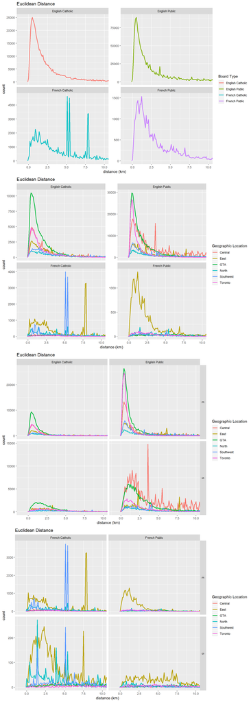

### 80th Percentile plots

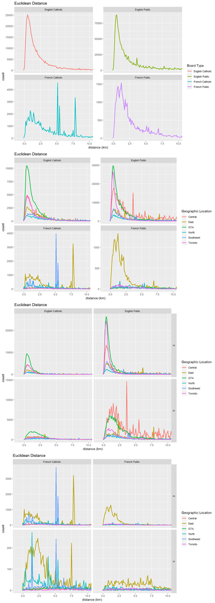

### 70th Percentile plots

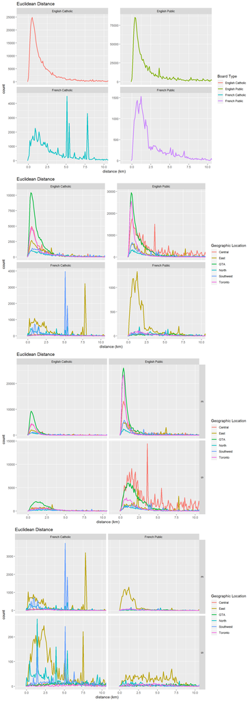

### 50th Percentile plots

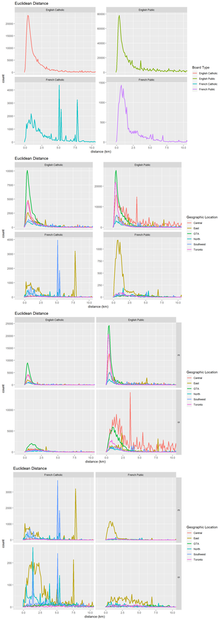

## Buffer Operation for Linear Regression

- Using `gbuffer()` to determine the treso zones that the 90th percentile distance touches for each school
- Setting up the multi-core to do `foreach()` loop is worth it once you are doing more than 100 fields
- 100 fields: 29s compared to 19s
- 1000 fields: 252s compared to 116s
- Test that `gBuffer()` is returning intended results.

## Linear Regression

- Combine the the datalist of buffered TRESO zones with the tibble containing socio-economic data
- Combine with the historical ADE and utilization data by school
- Segment the schools by board (at least)
- Build linear regression
- Explore other segmentations
- *TODO:* check the 0 matched MOF region